# Series de tiempo

Luis Fernando Apáez Álvarez

## Descripción

Lo que haremos en este proyecto es buscar ajustar un modelo estadístico a la serie de tiempo resultante de los precios de apertura de las acciones de Google de mayo del 2021 a octubre del 2022. Para ello implementaremos propiamente un análisis de la serie de tiempo buscando un modelo adecuado para ajustarle.

## Análisis Exploratorio

Comenzamos por cargar los datos

```r
data <- read.csv('df_goog.csv')

head(data)
```

```
##                        Date Open High Low Close
## 1 2021-05-10 00:00:00-04:00  119  119 117   117
## 2 2021-05-11 00:00:00-04:00  115  116 114   115
## 3 2021-05-12 00:00:00-04:00  113  114 112   112
## 4 2021-05-13 00:00:00-04:00  113  114 112   113
## 5 2021-05-14 00:00:00-04:00  115  116 114   116
## 6 2021-05-17 00:00:00-04:00  115  116 115   116
```

La variable que será de nuestro interés es `Open`, la cual se encuentra en la columna 2:

```r
head(data[2])
```

```
##   Open
## 1  119
## 2  115
## 3  113
## 4  113
## 5  115
## 6  115
```

```r
# Almacenamos los valores de Open
data_filtro <- data[2]

# Convertimos los datos a una serie de tiempo
data_filtro_st <- ts(data_filtro, frequency = 1)
```

Veamos un gráfico de los datos

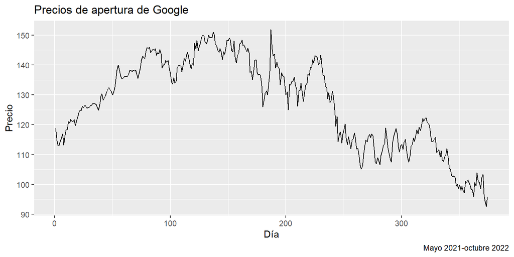

```r
# Graficamos
autoplot(data_filtro_st)  +
  # agregamos algunas etiquetas
  labs(title = "Precios de apertura de Google",
       x = "Día",
       y = "Precio",
       caption = "Mayo 2021-octubre 2022")
```

podemos notar cierto comportamiento de volatilidad en nuestros datos. Además, podemos notar cierta irregularidad entorno a la varianza, esto es, la varianza no es constante. Asimismo, es clara una tendencia a la baja.

Veamos algunas estadísticas

```r
summary(data_filtro_st)
```

```
##       Open
##  Min.   : 93
##  1st Qu.:115
##  Median :130
##  Mean   :127
##  3rd Qu.:140
##  Max.   :152
```

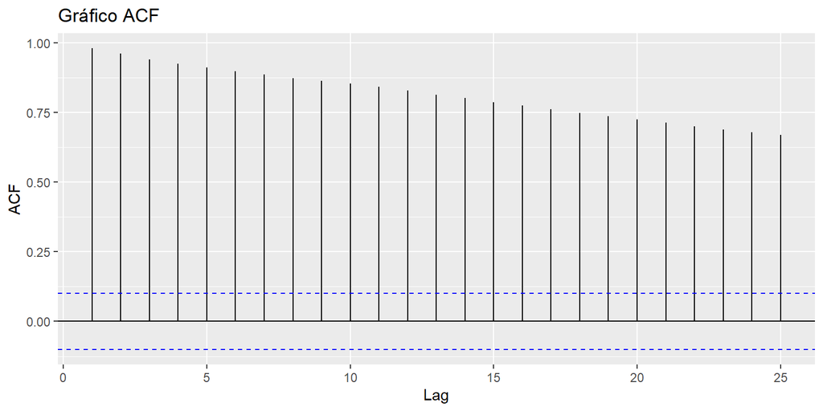

```r
ggAcf(data_filtro_st) + labs(title = "Gráfico ACF")
```

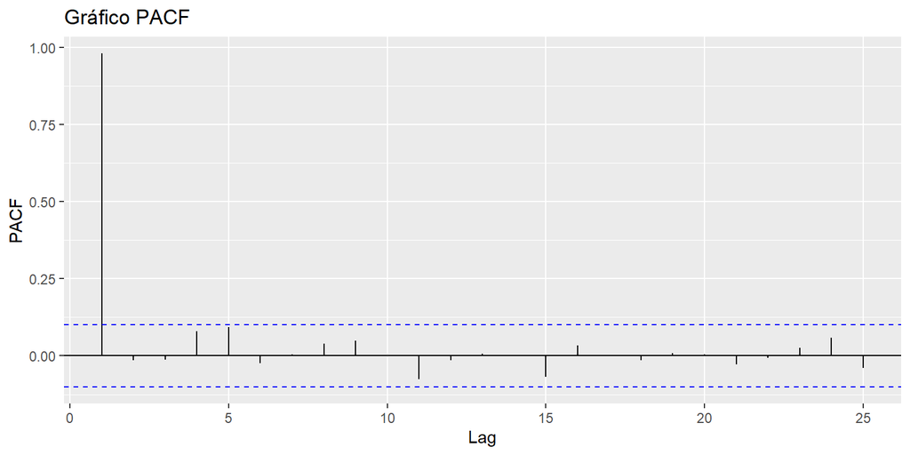

```r
ggPacf(data_filtro_st) + labs(title = "Gráfico PACF")
```

donde, del gráfico ACF vemos una fuerte correlación entre los datos de modo que, dado un dato $i$, tenemos que éste dependerá de todos los datos $j<i$, en cierta medida.

### Ajuste de la tendencia

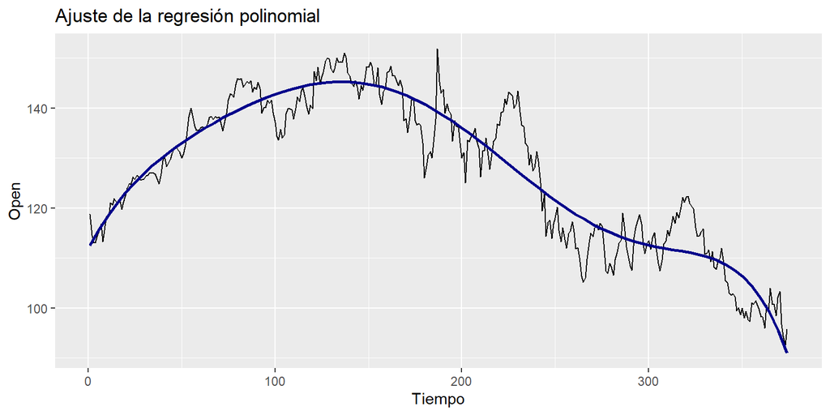

```r
t <- time(data_filtro_st)

# Creamos un dataframe auxiliar
df_aux = data.frame("Tiempo" = min(t):max(t),
                    "Open" = data[2])
# Graficamos la serie de tiempo
ggplot(data=df_aux, aes(x = Tiempo, y = Open)) +
  geom_line() +
  # Graficamos la regresion polinomial
  geom_smooth(method='lm', formula=y~x+I(x^2)+I(x^3)+I(x^4)+
              I(x^5)+I(x^6)+I(x^7), se=FALSE, col='darkblue')+
  labs(title = "Ajuste de la regresión polinomial")
```

veamos un ajuste bastante bueno entorno al comportamiento general de la tendencia de la serie de tiempo.

## Ajustando un modelo

Al inicio notamos que el comportamiento de la serie de tiempo sigue cierta volatilidad, lo culal podría ser factor importante a la hora de intentar ajustar un modelo del tipo ARIMA. Para comprobar lo anterior, realicemos un ajuste de la serie de tiempo a un modelo ARIMA:

```r
fit_arima <- auto.arima(data_filtro_st)
fit_arima
```

```
## Series: data_filtro_st
## ARIMA(0,1,0)
##
## sigma^2 = 6.03:  log likelihood = -864
## AIC=1731   AICc=1731   BIC=1735
```

lo cual parece indicar que un ajuste tantativo del modelo sería un $ARIMA(0,1,0)$.

Realizaremos un análisis rápido sobre los supuestos de este modelo:

- Normalidad: Gráficamente podemos observar que

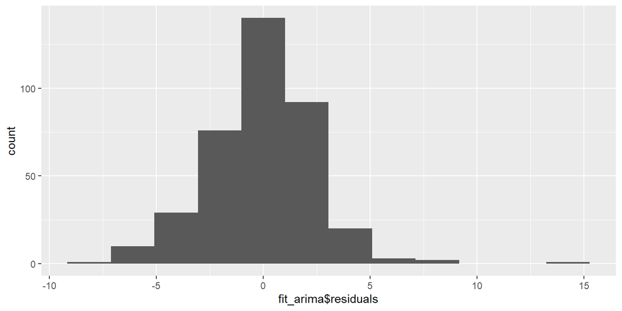

```r
# Graficamos un histograma de los residuales

ggplot(fit_arima, aes(x=fit_arima$residuals)) + geom_histogram(bins=12)
```

lo cual nos da posibles indicios de que los residuales sí siguen una distribución normal. Continuando

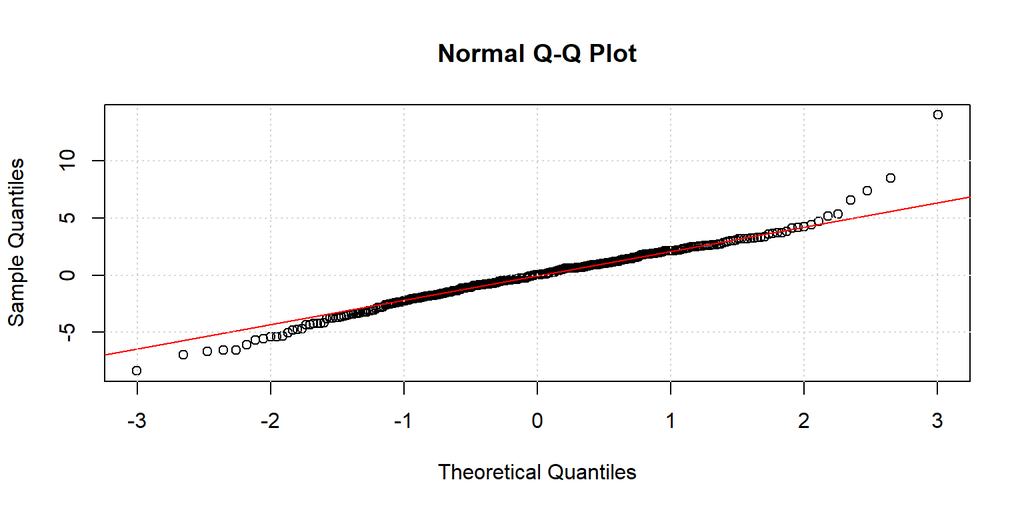

```r
qqnorm(fit_arima$residuals)
qqline(fit_arima$residuals, col="red")
grid()
```

al parecer los residuales siguen cierta normalidad, pero vemos un comportamiento peculiar en la cola superior. Comprobamos mediante prueba de hipótesis:

```r
# Prueba de Anderson-Darling
ad.test(fit_arima$residuals)
```

```
##
##  Anderson-Darling normality test
##
## data:  fit_arima$residuals
## A = 2, p-value = 6e-04
```

se rechaza $H_{0}$, esto es, se considera plasible asumir que los residuales no sigue una distribución normal, entonces este supuesto no se está cumpliendo.

- Independencia en las observaciones: Claramente este supuesto no se cumple, lo cual comprobamos mediante el siguiente gráfico de las correlaciones:

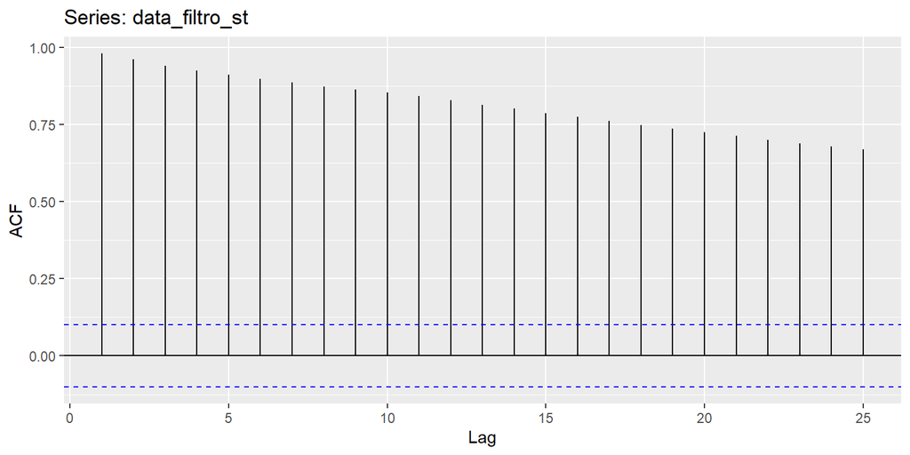

```r
ggAcf(data_filtro_st)
```

pues todas las observaciones se encuentran fuera del intervalo de confianza que nos asegura, bajo cierta confianza, que las observaciones son independientes entre sí.

Se concluye entonces que el modelo propuesto no está cumpliendo con los supuestos adecuados, de modo que éste es deficiente y poco preciso. El hecho anterior, en realidad, es algo que ya se sabía, pues dada la estructura y la naturaleza de los datos, el modelo ARIMA no es el adecuado para modelar los datos, en su lugar utilizaremos un modelo de heterocedasticidad condicional.